# 1. R in Action

## 3.5 plot, print, summary

R contains *generic* functions like `plot()`, `print()`, `summary()`, and `predict()`. Depending on the object *class* they are applied to, they do something different.

### 3.5.1 Example

Let’s look at two of the many behaviors of `plot()`:

```r
library(ggplot2)

# plot() applied to object of class "formula"
class(price ~ color)
```

```
## [1] "formula"
```

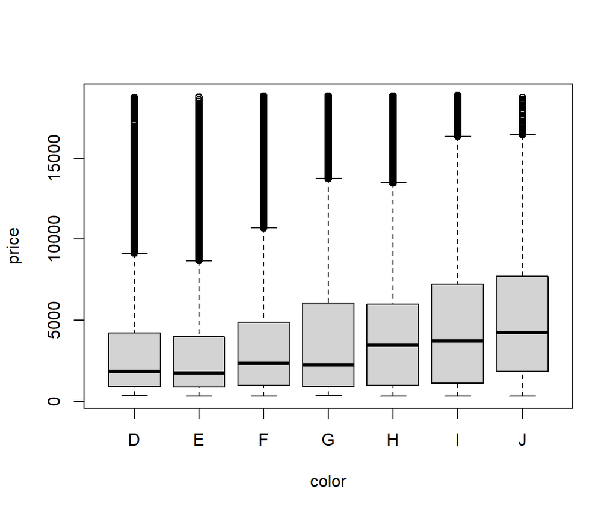

```r
plot(price ~ color, data = diamonds)
```

```r
# plot() applied to object of class "factor".
# Note: the first class "ordered" is skipped as it does not have its own plot method
class(diamonds$color)
```

```
## [1] "ordered" "factor"
```

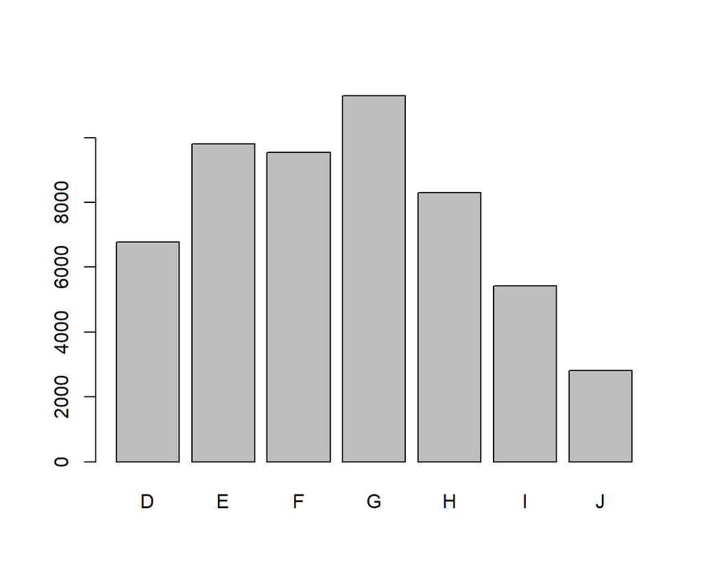

```r
plot(diamonds$color)
```

This so-called S3 object oriented system works roughly like this: The generic function calls `UseMethod()`, which selects the class-specific *method* of the form `[generic].[class]()`, which is then being invoked. In above situation, `plot()` calls `UseMethod()`, which then calls `plot.factor()`.

Following this logic, we can write our own `print()` methods, for example. It is also possible to define new *generic* functions, but we will not need that here.

### 3.5.2 Example

Let’s create an object of type “student” with its own `print()` method.

```r
# Function that creates an object of class "student"
student <- function(given_name, family_name) {
  out <- list(
    given_name = given_name,
    family_name = family_name
  )
  class(out) <- "student"
  out
}

me <- student("Michael", "Mayer")
me # same as print(me)
```

```
## $given_name
## [1] "Michael"
##
## $family_name
## [1] "Mayer"
##
## attr(,"class")
## [1] "student"
```

```r
# Nothing special so far. We first need a print() method for the "student" class
print.student <- function(x, ...) {
  cat("Hi, I'm", x$given_name, x$family_name)
  invisible(x)
}

print(me) # same as me
```

```
## Hi, I'm Michael Mayer
```

This construction is often used in R.

**Remarks**

- To see all (loaded) class methods of a generic function, type `methods([generic])`. Thus, `methods(plot)` will show all loaded plot methods.
- If an object has multiple classes, `UseMethod()` will search the first class that has a method for the given generic. If none is found, the default method is called, e.g., `print.default()`.
- The ellipsis `...` is a placeholder for other function arguments. It is usually just passed to another function.
- To learn much more about classes, methods, and S3, see Wickham (2015a).

# 4 Exercises

1. Load the data `dataCar` from the package “insuranceData”. It represents claim data on vehicle insurance policies from 2004 to 2005. Some variables like “gender” describe the policy holder, others like “veh_age” the vehicle, and some variables carry information on claims, e.g., “numclaims”. Each row represents policy information valid in a certain time window. Use the pipe, “dplyr”, and “ggplot2” to solve the following tasks.
   1. Draw barplots of the discrete variables “numclaims”, “agecat” (categorized driver age), and “gender”.
   2. Draw a histogram of the vehicle value “veh_value” (in 10’000 Australian Dollars). Truncate values above 7 (this means: if a value is larger than 7, set it to 7).
   3. Calculate the average number of claims per level of “agecat” and visualize the result as a scatterplot. Interpret the result.
   4. Bin “veh_value” into quartiles and analyze its association with the number of claims as in 1c.
   5. Use the “plotly” package to turn the plot from d. interactive.

   ```r
   library(tidyverse)
   library(insuranceData)
   library(plotly)

   data(dataCar)
   ```

2. Create an R Markdown file that contains all answers to Exercise 1. Knit the report to HTML. Make sure that the resulting HTML looks neat and clean, so that you could hand it over to someone else.
3. The sieve of Eratosthenes is an ancient algorithm to get all prime numbers up to any given limit $n$, see [Wikipedia](https://en.wikipedia.org/wiki/Sieve_of_Eratosthenes). Write a function `sieve_of_eratosthenes(n)` that returns all prime numbers up to $n$. Benchmark the results for $n = 10^5$ with the package “bench”. Mind your coding style!
4. In Exercise 1c, we have calculated and plotted the average number of claims per level of “agecat” in the `dataCar` data.
   1. Write a function `avg_claim_counts(v)` that provides such a visualization for any discrete variable `v`.
   2. Extend this function with a second argument `interactive` to control whether the resulting plot is interactive or not.
5. Extend the “student” class from Section “plot, print, summary” by the optional information “semester”. It represents the number of semesters the student is already registered. Add a `summary()` method that would neatly print the name and the semester of the student.

# 5 Summary

In this first chapter, we have used R as a powerful tool for data preparation and descriptive analysis. Furthermore, we met important aspects of writing functions.

# References

Wickham, Hadley. 2015a. *Advanced R*. CRC Press. https://adv-r.hadley.nz/index.html.

Wickham, Hadley. 2015b. *R Packages: Organize, Test, Document, and Share Your Code*. O’Reilly Media. https://r-pkgs.org/.

Wickham, Hadley, and Garrett Grolemund. 2017. *R for Data Science: Import, Tidy, Transform, Visualize, and Model Data*. O’Reilly Media. http://r4ds.had.co.nz/.

Wilkinson, Leland. 2005. *The Grammar of Graphics (Statistics and Computing)*. Springer-Verlag.

Xie, Yihui, J. J. Allaire, and Garrett Grolemund. 2018. *R Markdown: The Definitive Guide*. Chapman; Hall/CRC. https://bookdown.org/yihui/rmarkdown.